# Data Analysis to identify the potential customers who have a higher probability of purchasing the loan

The bank has customer data with various charectoristics of customers. They have built new product - personal loan and they are making campaign to attract more customers and last campaign has given 9% success. This has encouraged the retail marketing department to devise campaign with better target marketing to increase the sucess ratio with minimal budget

The main requirement :

```
1. To sell more personal lona products to Bnak customers
2. Better target marketing and increase the success ratio with minimul budget
3. Identify customers with higher probability of purchasing personal loan
```

Increase the success ratio but at the same time at less budget

Learnings from last campaign since bank got 9% success:

```
1. Is there any association between personal charectoristic and getting personal loan
2. What are those major charectoristics which has got association with personal and what is the strength of the association.
```

Objective: The classification goal is to predict the likelihood of a liability customer buying personal loans.

Steps and tasks:

1. Readthecolumndescriptionandensureyouunderstandeachattributewell
2. Study the data distribution in each attribute, share your findings
3. Get the target column distribution. Your comments
4. Split the data into training and test set in the ratio of 70:30 respectively
5. Use different classification models (Logistic, K-NN and Naïve Bayes) to predict the likelihood of a liability customer buying personal loans
6. Print the confusion matrix for all the above models
7. Give your reasoning on which is the best model in this case and why it performs better?

```python
import pandas as pd
import numpy as np
import matplotlib.pyplot as plt
import seaborn as sns
%matplotlib inline
sns.set(style='ticks')
from sklearn.neighbors import KNeighborsClassifier
from sklearn import model_selection
from sklearn.naive_bayes import GaussianNB
```

```python
data = pd.read_csv('/users/rajuhegde/desktop/Greatlearning/GLprojects/Bank_Personal_Loan_Modelling.csv')
```

```python
data.head()
```

|  | ID | Age | Experience | Income | ZIP Code | Family | CCAvg | Education | Mortgage | Personal Loan | Securities Account | CD Account | Online | CreditCard |
| --- | --- | --- | --- | --- | --- | --- | --- | --- | --- | --- | --- | --- | --- | --- |
| 0 | 1 | 25 | 1 | 49 | 91107 | 4 | 1.6 | 1 | 0 | 0 | 1 | 0 | 0 | 0 |
| 1 | 2 | 45 | 19 | 34 | 90089 | 3 | 1.5 | 1 | 0 | 0 | 1 | 0 | 0 | 0 |
| 2 | 3 | 39 | 15 | 11 | 94720 | 1 | 1.0 | 1 | 0 | 0 | 0 | 0 | 0 | 0 |
| 3 | 4 | 35 | 9 | 100 | 94112 | 1 | 2.7 | 2 | 0 | 0 | 0 | 0 | 0 | 0 |
| 4 | 5 | 35 | 8 | 45 | 91330 | 4 | 1.0 | 2 | 0 | 0 | 0 | 0 | 0 | 1 |

```python
data.columns
```

```
Index(['ID', 'Age', 'Experience', 'Income', 'ZIP Code', 'Family', 'CCAvg',
       'Education', 'Mortgage', 'Personal Loan', 'Securities Account',
       'CD Account', 'Online', 'CreditCard'],
      dtype='object')
```

Information on the attributes : It can be devided as below

a. The variable ID does not add any interesting contribution. There is no association with personal loan and ccustomer ID. we can neglect this information.

The Binary category have five variables as below : a. Personal Loan - Did this customer accept the personal loan offered in last campaign? this is our target variable b.Security account - Does the customer have a securities account with the bank? c. CD account - Does the customer have a certification of deposit ( CD account) with the bank? d.Online - Does the customer use internet banking facility? e. Credit card - Does the customer use a credit card issued by Thera bank?

```
Interval Variables are as below :

    1.Age - Age of the customer
    2.Experience - Years of experience
    3.Income - Annual income in dollars
    4.CCAvg - Average credit card spending
    5.Mortgage - Value of House Mortgage

Ordinal Categorical Variables are :

    1. Family - Family size of the customer
    2.Education - Education level

The nominal variable is :
    1. ID
    2.Zip Code
```

```python
data.shape
```

```
(5000, 14)
```

```python
data.info()
```

```
<class 'pandas.core.frame.DataFrame'>
RangeIndex: 5000 entries, 0 to 4999
Data columns (total 14 columns):
ID                    5000 non-null int64
Age                   5000 non-null int64
Experience            5000 non-null int64
Income                5000 non-null int64
ZIP Code              5000 non-null int64
Family                5000 non-null int64
CCAvg                 5000 non-null float64
Education             5000 non-null int64
Mortgage              5000 non-null int64
Personal Loan         5000 non-null int64
Securities Account    5000 non-null int64
CD Account            5000 non-null int64
Online                5000 non-null int64
CreditCard            5000 non-null int64
dtypes: float64(1), int64(13)
memory usage: 547.0 KB
```

```python
# No of columns have null values
data.apply(lambda x : sum(x.isnull()))
```

```
ID                    0
Age                   0
Experience            0
Income                0
ZIP Code              0
Family                0
CCAvg                 0
Education             0
Mortgage              0
Personal Loan         0
Securities Account    0
CD Account            0
Online                0
CreditCard            0
dtype: int64
```

```python
# Eye balling the data
data.describe().transpose()
```

|  | count | mean | std | min | 25% | 50% | 75% | max |
| --- | --- | --- | --- | --- | --- | --- | --- | --- |
| ID | 5000.0 | 2500.500000 | 1443.520003 | 1.0 | 1250.75 | 2500.5 | 3750.25 | 5000.0 |
| Age | 5000.0 | 45.338400 | 11.463166 | 23.0 | 35.00 | 45.0 | 55.00 | 67.0 |
| Experience | 5000.0 | 20.104600 | 11.467954 | -3.0 | 10.00 | 20.0 | 30.00 | 43.0 |
| Income | 5000.0 | 73.774200 | 46.033729 | 8.0 | 39.00 | 64.0 | 98.00 | 224.0 |
| ZIP Code | 5000.0 | 93152.503000 | 2121.852197 | 9307.0 | 91911.00 | 93437.0 | 94608.00 | 96651.0 |
| Family | 5000.0 | 2.396400 | 1.147663 | 1.0 | 1.00 | 2.0 | 3.00 | 4.0 |
| CCAvg | 5000.0 | 1.937938 | 1.747659 | 0.0 | 0.70 | 1.5 | 2.50 | 10.0 |
| Education | 5000.0 | 1.881000 | 0.839869 | 1.0 | 1.00 | 2.0 | 3.00 | 3.0 |
| Mortgage | 5000.0 | 56.498800 | 101.713802 | 0.0 | 0.00 | 0.0 | 101.00 | 635.0 |
| Personal Loan | 5000.0 | 0.096000 | 0.294621 | 0.0 | 0.00 | 0.0 | 0.00 | 1.0 |
| Securities Account | 5000.0 | 0.104400 | 0.305809 | 0.0 | 0.00 | 0.0 | 0.00 | 1.0 |
| CD Account | 5000.0 | 0.060400 | 0.238250 | 0.0 | 0.00 | 0.0 | 0.00 | 1.0 |
| Online | 5000.0 | 0.596800 | 0.490589 | 0.0 | 0.00 | 1.0 | 1.00 | 1.0 |
| CreditCard | 5000.0 | 0.294000 | 0.455637 | 0.0 | 0.00 | 0.0 | 1.00 | 1.0 |

```python
# Finding unique data
data.apply(lambda x : len(x.unique()))
```

```
ID                    5000
Age                     45
Experience              47
Income                 162
ZIP Code               467
Family                   4
CCAvg                  108
Education                3
Mortgage               347
Personal Loan            2
Securities Account       2
CD Account               2
Online                   2
CreditCard               2
dtype: int64
```

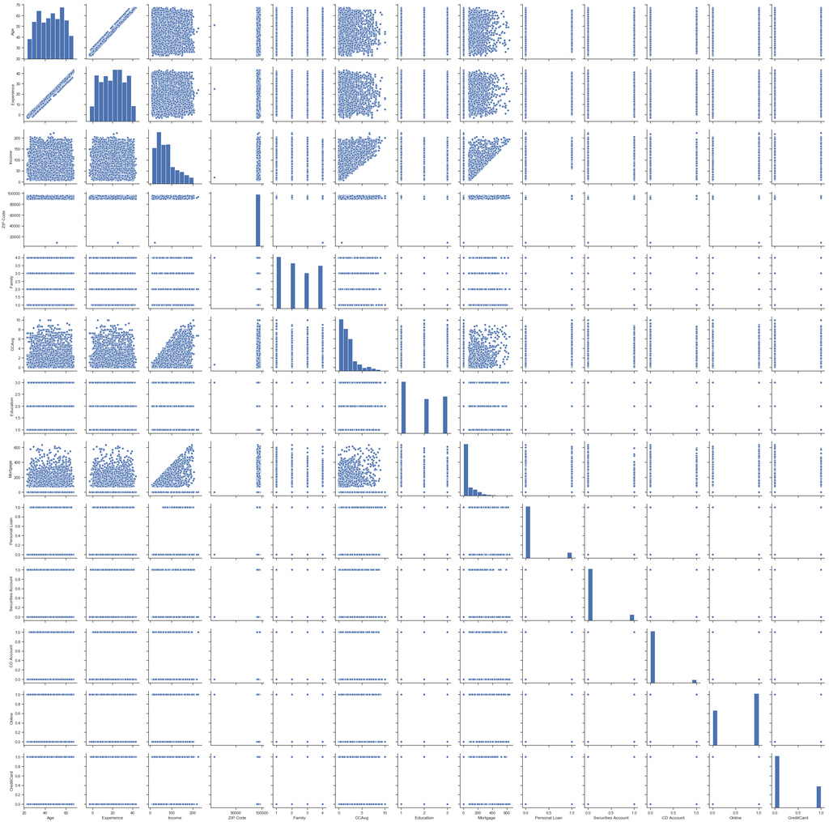

```python
sns.pairplot(data.iloc[:,1:])
```

Observations as below :

[output not shown]

```python
# there are 52 records with negative experience. before we proceed further, we need to clean this data.
data[data['Experience']<0]['Experience'].count()
```

```
52
```

```python
# Clean the nagative variable
PExp = data.loc[data['Experience']>0]
NExp = data. Experience < 0
column_name = 'Experience'
mylist = data.loc[NExp]['ID'].tolist() # geting the customer ID who has negative experinces
```

```python
NExp.value_counts()
```

```
False    4948
True       52
Name: Experience, dtype: int64
```

```python
# for the record with the ID, get the value of Age column
# for the record with the ID, get the value of education column
# filter the records matching the above criteria from the data frame which has records with positive experiences and take the median
# apply the median back to the location which had negative experiences
```

```python
for id in mylist:
    age = data.loc[np.where(data['ID']==id)]['Age'].tolist()[0]
    education = data.loc[np.where(data['ID']==id)]['Education'].tolist()[0]
    df_filter = PExp[(PExp.Age == age) & (PExp.Education == education)]
    exp = df_filter['Experience'].median()
    data.loc[data.loc[np.where(data['ID']==id)].index, 'Experience'] = exp
```

```python
#checking if there are records with negative experiences
data[data['Experience']<0]['Experience'].count()
```

```
0
```

```python
data.describe().transpose()
```

|  | count | mean | std | min | 25% | 50% | 75% | max |
| --- | --- | --- | --- | --- | --- | --- | --- | --- |
| ID | 5000.0 | 2500.500000 | 1443.520003 | 1.0 | 1250.75 | 2500.5 | 3750.25 | 5000.0 |
| Age | 5000.0 | 45.338400 | 11.463166 | 23.0 | 35.00 | 45.0 | 55.00 | 67.0 |
| Experience | 4971.0 | 20.243211 | 11.359189 | 0.0 | 10.00 | 20.0 | 30.00 | 43.0 |
| Income | 5000.0 | 73.774200 | 46.033729 | 8.0 | 39.00 | 64.0 | 98.00 | 224.0 |
| ZIP Code | 5000.0 | 93152.503000 | 2121.852197 | 9307.0 | 91911.00 | 93437.0 | 94608.00 | 96651.0 |
| Family | 5000.0 | 2.396400 | 1.147663 | 1.0 | 1.00 | 2.0 | 3.00 | 4.0 |
| CCAvg | 5000.0 | 1.937938 | 1.747659 | 0.0 | 0.70 | 1.5 | 2.50 | 10.0 |
| Education | 5000.0 | 1.881000 | 0.839869 | 1.0 | 1.00 | 2.0 | 3.00 | 3.0 |
| Mortgage | 5000.0 | 56.498800 | 101.713802 | 0.0 | 0.00 | 0.0 | 101.00 | 635.0 |
| Personal Loan | 5000.0 | 0.096000 | 0.294621 | 0.0 | 0.00 | 0.0 | 0.00 | 1.0 |
| Securities Account | 5000.0 | 0.104400 | 0.305809 | 0.0 | 0.00 | 0.0 | 0.00 | 1.0 |
| CD Account | 5000.0 | 0.060400 | 0.238250 | 0.0 | 0.00 | 0.0 | 0.00 | 1.0 |
| Online | 5000.0 | 0.596800 | 0.490589 | 0.0 | 0.00 | 1.0 | 1.00 | 1.0 |
| CreditCard | 5000.0 | 0.294000 | 0.455637 | 0.0 | 0.00 | 0.0 | 1.00 | 1.0 |

# Influence of income and education on personal loan

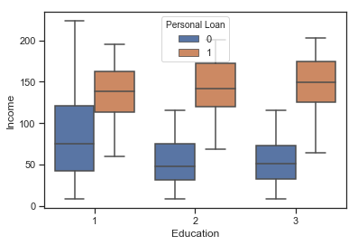

```python
sns.boxplot(x='Education',y='Income',hue='Personal Loan',data = data)
```

Result : It seems the customer having education level 1 is having more income. however the people who has taken personal loan have same level of income

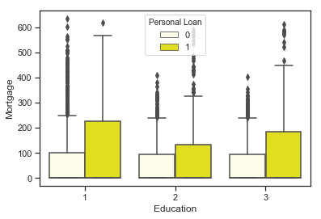

```python
sns.boxplot(x='Education',y='Mortgage',hue = 'Personal Loan', data=data, color = 'yellow')
```

Result : From the above chart we understood that,compare to the people who dont have personal loan, people who have personal loan have high mortgage

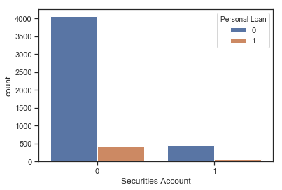

```python
sns.countplot(x='Securities Account',data=data,hue='Personal Loan')
```

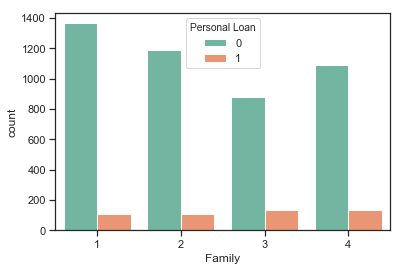

```python
sns.countplot(x='Family', data=data,hue='Personal Loan', palette='Set2')
```

Result : family size does't have any impact on personal loan, but families with size 3 and 4 are more likely to take loan. this is very useful information for future campaign

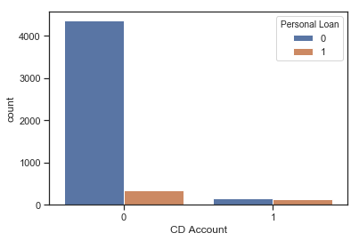

```python
sns.countplot(x='CD Account',data=data,hue='Personal Loan')
```

Result : Customer who does not have CD account also have loan but very few people but people who have CDAccount have loan as well.

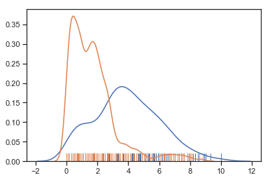

```python
# CCAvg with loan and without loan
CCAwith_loan = data.loc[data['Personal Loan']==1]
CCAwithout_loan = data.loc[data['Personal Loan']==0]

sns.distplot(CCAwith_loan[['CCAvg']], hist=False, rug=True)
sns.distplot(CCAwithout_loan[['CCAvg']], hist=False, rug=True)
```

```python
print('Credit card spending of Non-Loan customers : ',CCAwithout_loan['CCAvg'].median()*1000 )

print('Credit card spending of Loan customers : ',CCAwith_loan['CCAvg'].median()*1000 )
```

```
Credit card spending of Non-Loan customers :  1400.0
Credit card spending of Loan customers :  3800.0
```

Result : The graph shows the people who have personal loan have higher CC average. Average credit card spending with a median of 3800 indicates higher probability of personal loan. This could be useful information for upcoming campaign.

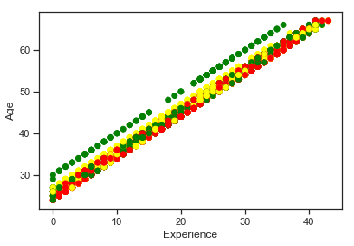

```python
fig,ax =plt.subplots()
colors = {1:'red', 2:'yellow', 3: 'green'}
ax.scatter(data['Experience'],data['Age'], c=data['Education'].apply(lambda x: colors[x]))
plt.xlabel('Experience')
plt.ylabel('Age')
```

Result : Experince and age have positive correlation. There is a gap in the mid forties of age and also more people under graduate. colors shows the education level

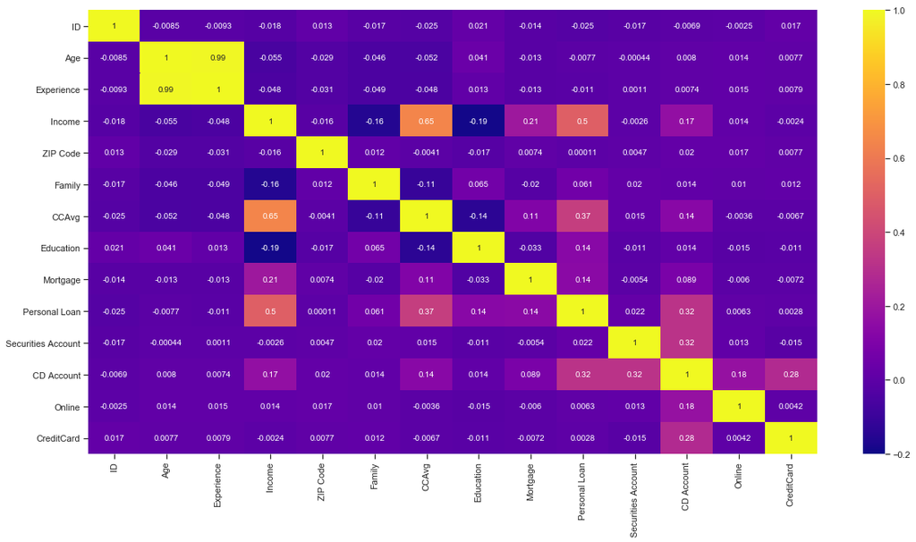

```python
#Correlation with heat map
corr = data.corr()
plt.figure(figsize=(20,10))
sns.heatmap(corr,annot=True,cmap="plasma",vmin=-0.2,vmax=1)
```

Observation :

```
1. Age and Experince is highly correlated
2. Personal loan has maximum correlation with : (income,CCAvg,CD Account, Mortgage & Education)
3. Mortgage has moderate correlation with income
4. Income influences CCAvg, Personal Loan, Mortgage, CD Account.
```

# Split Dataset into Training and test 70:30 ratio

```python
data.columns
```

```
Index(['ID', 'Age', 'Experience', 'Income', 'ZIP Code', 'Family', 'CCAvg',
       'Education', 'Mortgage', 'Personal Loan', 'Securities Account',
       'CD Account', 'Online', 'CreditCard'],
      dtype='object')
```

1. Seperating the dependent and Independent (target) vaiables into two different data.
2. Since experience and age are 99% correlated, lets consider only age for the model building.
3. Since ID doesnt have any effect on the data and is only a categorical variable, we shall drop the same.

```python
X=data.drop(['ID','Experience','Personal Loan'], axis=1)
y=data['Personal Loan']
```

```python
X.columns
```

```
Index(['Age', 'Income', 'ZIP Code', 'Family', 'CCAvg', 'Education', 'Mortgage',
       'Securities Account', 'CD Account', 'Online', 'CreditCard'],
      dtype='object')
```

```python
from sklearn.model_selection import train_test_split
from sklearn import metrics

X_train,X_test,y_train,y_test = train_test_split(X,y,test_size = 0.3, random_state=10)
```

to check the effect of scaling on teh dataset, let us creat another set of data with scaling function applied to it

```python
from sklearn import preprocessing
ZX = preprocessing.scale(X)
ZX_train,ZX_test,y_train,y_test = train_test_split(ZX,y,test_size = 0.3,random_state=10)
```

# Model Building - Logistic Regression

```python
#Imported libraries
from sklearn.linear_model import LogisticRegression
class1 = LogisticRegression()
#Apply training data to Logistics Regression Model
class1.fit(X_train, y_train)
#Predict the test results
y_predict = class1.predict(X_test)

#Calculate the coefficients of logistic regression model
t=list(X_train.columns)
coef_df = pd.DataFrame(class1.coef_,columns=t)
coef_df['intercept']=class1.intercept_
print(coef_df)
```

```
        Age    Income  ZIP Code    Family     CCAvg  Education  Mortgage  \
0  0.007155  0.037557 -0.000071  0.015505  0.005647   0.018257  0.000537

   Securities Account  CD Account    Online  CreditCard  intercept
0            0.001144    0.004903 -0.000517   -0.000134  -0.000084
```

```python
# calculate the model score and confusion matrix
class1_score = class1.score(X_test,y_test)
print(class1_score)
print(metrics.confusion_matrix(y_test, y_predict))
print(metrics.classification_report(y_test,y_predict))
```

```
0.8993333333333333
[[1302   58]
 [  93   47]]
              precision    recall  f1-score   support

           0       0.93      0.96      0.95      1360
           1       0.45      0.34      0.38       140

   micro avg       0.90      0.90      0.90      1500
   macro avg       0.69      0.65      0.66      1500
weighted avg       0.89      0.90      0.89      1500
```

Model Accuracy is 0.8993~0.90

True Positives = 1302

True Negative = 47

False Positive = 93

Flase Nagative = 58

```python
#Apply scaled training data to the logistics regression model
class2 = LogisticRegression()
class2.fit(ZX_train,y_train)

#Predict the test results
y_predict = class2.predict(ZX_test)

#Calculate the coefficient of logistics regression model

coef_df  = pd.DataFrame(class2.coef_,columns=t)
coef_df['Intercept'] = class2.intercept_
print(coef_df)
```

```
        Age   Income  ZIP Code    Family     CCAvg  Education  Mortgage  \
0  0.091097  2.43813  -0.02636  0.758031  0.181394   1.338921  0.001545

   Securities Account  CD Account    Online  CreditCard  Intercept
0           -0.209886    0.843772 -0.355392   -0.471615  -4.467691
```

```python
class2_score = class2.score(ZX_test, y_test)
print(class2_score)
print(metrics.confusion_matrix(y_test,y_predict))
print(metrics.classification_report(y_test,y_predict))
```

```
0.9526666666666667
[[1339   21]
 [  50   90]]
              precision    recall  f1-score   support

           0       0.96      0.98      0.97      1360
           1       0.81      0.64      0.72       140

   micro avg       0.95      0.95      0.95      1500
   macro avg       0.89      0.81      0.85      1500
weighted avg       0.95      0.95      0.95      1500
```

Model Accuracy has improved to 0.95

True Positive = 1339

True Negative = 90

False Positive = 50

False Nagative = 21

# Model Building - Naive Bayes

```python
from sklearn.naive_bayes import GaussianNB
classNB = GaussianNB()
classNB.fit(X_train,y_train)
y_predict = classNB.predict(X_test)
classNB_score = classNB.score(X_test,y_test)
print(classNB_score)
print(metrics.confusion_matrix(y_test,y_predict))
print(metrics.classification_report(y_test,y_predict))
```

```
0.886
[[1243  117]
 [  54   86]]
              precision    recall  f1-score   support

           0       0.96      0.91      0.94      1360
           1       0.42      0.61      0.50       140

   micro avg       0.89      0.89      0.89      1500
   macro avg       0.69      0.76      0.72      1500
weighted avg       0.91      0.89      0.90      1500
```

Model Accuracy is 0.886

True Positive = 1243

True negative = 86

False Positives = 54

false negative = 117

```python
# From scaled data

classNB2 = GaussianNB()
classNB2.fit(ZX_train,y_train)
y_predict = classNB2.predict(ZX_test)
classNB2_score = classNB.score(ZX_test,y_test)
print(classNB2_score)
print(metrics.confusion_matrix(y_test,y_predict))
print(metrics.classification_report(y_test,y_predict))
```

```
0.9066666666666666
[[1234  126]
 [  56   84]]
              precision    recall  f1-score   support

           0       0.96      0.91      0.93      1360
           1       0.40      0.60      0.48       140

   micro avg       0.88      0.88      0.88      1500
   macro avg       0.68      0.75      0.71      1500
weighted avg       0.90      0.88      0.89      1500
```

True Positive = 1234

True Nagative = 84

False Positive = 56

False Nagative = 126

```python
from sklearn.neighbors import KNeighborsClassifier
NNH_a = KNeighborsClassifier(n_neighbors=3,weights ='distance')
NNH_a.fit(X_train,y_train)
y_predict=NNH_a.predict(X_test)
NNH_a_score = NNH_a.score(X_test,y_test)
print(NNH_a_score)
print(metrics.confusion_matrix(y_test,y_predict))
print(metrics.classification_report(y_test,y_predict))
```

```
0.8813333333333333
[[1280   80]
 [  98   42]]
              precision    recall  f1-score   support

           0       0.93      0.94      0.93      1360
           1       0.34      0.30      0.32       140

   micro avg       0.88      0.88      0.88      1500
   macro avg       0.64      0.62      0.63      1500
weighted avg       0.87      0.88      0.88      1500
```

Model accuracy is 0.881

True Positive = 1280

True Negative = 42

False Positive = 98

False Negative = 80

```python
NNH_b = KNeighborsClassifier(n_neighbors=3,weights = 'distance')
NNH_b.fit(ZX_train,y_train)
y_predict=NNH_b.predict(ZX_test)
NNH_b_score = NNH_b.score(ZX_test,y_test)
print(NNH_b_score)
print(metrics.confusion_matrix(y_test,y_predict))
print(metrics.classification_report(y_test,y_predict))
```

```
0.964
[[1352    8]
 [  46   94]]
              precision    recall  f1-score   support

           0       0.97      0.99      0.98      1360
           1       0.92      0.67      0.78       140

   micro avg       0.96      0.96      0.96      1500
   macro avg       0.94      0.83      0.88      1500
weighted avg       0.96      0.96      0.96      1500
```

Model accuracy has increased 0.964

True Positive = 1352

False Positive = 46

False nagative = 8

True Nagative = 94

```python
Accuracy_before_scaling = {'Logistics Regression': class1_score, 'Naive Bayes': classNB_score, 'K-Nearest Neighbors':NNH_a_score}
Accuracy_after_scaling = {'Logistics Regression': class2_score, 'Naive Bayes': classNB2_score, 'K-Nearest Neighbors':NNH_b_score}
print('Overall Model Accuracy before scaling')
print(Accuracy_before_scaling)
print('\n')
print('Overall Model Accuracy after scaling')
print(Accuracy_after_scaling)
```

```
Overall Model Accuracy before scaling
{'Logistics Regression': 0.8993333333333333, 'Naive Bayes': 0.886, 'K-Nearest Neighbors': 0.8813333333333333}


Overall Model Accuracy after scaling
{'Logistics Regression': 0.9526666666666667, 'Naive Bayes': 0.9066666666666666, 'K-Nearest Neighbors': 0.964}
```

From the above, we can conclude that KNN algorithm with scaled data gives us the best accuracy of 96.4% as well as the Least Type 1 and Type 2 errors.

hence, in the current set of algorithms applied on the available data,it seems to be the best choice to predict the customers who will accept the personal loan.